# ETAPA 1 - Tratamento, Tipagem e EDA - `pedidos.csv` e `avaliacoes.csv`

Preparação dos dados.

| Bloco | Tabela | O que acontece |
| --- | --- | --- |
| 1 | `pedidos.csv` | Inspeção → Tipagem → Limpeza → Features → EDA |
| 2 | `avaliacoes.csv` | Inspeção → Tipagem → Limpeza → Features → EDA |
| 3 | Join final | Merge → EDA cruzada → Salvamento |

**Output:** `dataset_tratado.csv`

## 0. Imports e Configuração

```python
from google.colab import drive
drive.mount('/content/drive')
```

```python
import os
import numpy as np
import pandas as pd
import matplotlib.pyplot as plt
import matplotlib.ticker as mticker
import seaborn as sns
import warnings

warnings.filterwarnings('ignore')
%matplotlib inline

# Estilo global/padrão dos gráficos
sns.set_theme(style='whitegrid', palette='muted', font_scale=1.05)
plt.rcParams.update({
    'axes.spines.top'   : False,
    'axes.spines.right' : False,
    'figure.dpi'        : 110,
})

SCORE_COLORS = {1:'#EF233C', 2:'#F4A261', 3:'#FFD166', 4:'#06D6A0', 5:'#4361EE'}
PAL_5        = [SCORE_COLORS[i] for i in range(1, 6)]

# Paths
try:
    from google.colab import drive
    drive.mount('/content/drive')
    BASE = '/content/drive/MyDrive/Projeto Integrador/Banco_de_Dados_PII3_AWS'
except ImportError:
    BASE = '.'   # local — coloque todos os arquivos na mesma pasta

PATH_PEDIDOS    = f'{BASE}/pedidos.csv'
PATH_AVALIACOES = f'{BASE}/avaliacoes.csv'
PATH_OUTPUT     = f'{BASE}/dataset_tratado.csv'

print('✅ Configuração OK')
```

```
✅ Configuração OK
```

## 1. `pedidos.csv`

Contém informações de ciclo de vida de cada pedido: datas de compra, aprovação, despacho, entrega real e estimada.

### 1.1 Carga e inspeção inicial

```python
pedidos = pd.read_csv(PATH_PEDIDOS)

print(f'Shape       : {pedidos.shape}')
print(f'Linhas      : {len(pedidos):,}')
print(f'Colunas     : {pedidos.shape[1]}')
print()
print('Dtypes (antes do tratamento)')
print(pedidos.dtypes.to_string())
print()
print('Nulos por coluna')
nulls = pedidos.isna().sum()
pct   = (nulls / len(pedidos) * 100).round(2)
print(pd.DataFrame({'nulos': nulls, '%': pct}).to_string())
```

```
Shape       : (99441, 8)
Linhas      : 99,441
Colunas     : 8

Dtypes (antes do tratamento)
order_id                         object
customer_id                      object
order_status                     object
order_purchase_timestamp         object
order_approved_at                object
order_delivered_carrier_date     object
order_delivered_customer_date    object
order_estimated_delivery_date    object

Nulos por coluna
                               nulos     %
order_id                           0  0.00
customer_id                        0  0.00
order_status                       0  0.00
order_purchase_timestamp           0  0.00
order_approved_at                160  0.16
order_delivered_carrier_date    1783  1.79
order_delivered_customer_date   2965  2.98
order_estimated_delivery_date      0  0.00
```

```python
pedidos.head(5)
```

|  | order_id | customer_id | order_status | order_purchase_timestamp | order_approved_at | order_delivered_carrier_date | order_delivered_customer_date | order_estimated_delivery_date |
| --- | --- | --- | --- | --- | --- | --- | --- | --- |
| 0 | e481f51cbdc54678b7cc49136f2d6af7 | 9ef432eb6251297304e76186b10a928d | delivered | 2017-10-02 10:56:33 | 2017-10-02 11:07:15 | 2017-10-04 19:55:00 | 2017-10-10 21:25:13 | 2017-10-18 00:00:00 |
| 1 | 53cdb2fc8bc7dce0b6741e2150273451 | b0830fb4747a6c6d20dea0b8c802d7ef | delivered | 2018-07-24 20:41:37 | 2018-07-26 03:24:27 | 2018-07-26 14:31:00 | 2018-08-07 15:27:45 | 2018-08-13 00:00:00 |
| 2 | 47770eb9100c2d0c44946d9cf07ec65d | 41ce2a54c0b03bf3443c3d931a367089 | delivered | 2018-08-08 08:38:49 | 2018-08-08 08:55:23 | 2018-08-08 13:50:00 | 2018-08-17 18:06:29 | 2018-09-04 00:00:00 |
| 3 | 949d5b44dbf5de918fe9c16f97b45f8a | f88197465ea7920adcdbec7375364d82 | delivered | 2017-11-18 19:28:06 | 2017-11-18 19:45:59 | 2017-11-22 13:39:59 | 2017-12-02 00:28:42 | 2017-12-15 00:00:00 |
| 4 | ad21c59c0840e6cb83a9ceb5573f8159 | 8ab97904e6daea8866dbdbc4fb7aad2c | delivered | 2018-02-13 21:18:39 | 2018-02-13 22:20:29 | 2018-02-14 19:46:34 | 2018-02-16 18:17:02 | 2018-02-26 00:00:00 |

### 1.2 Tipagem

- Colunas de **`data`** `object`. Convertemos para `datetime64`.
- Colunas de **`ID`**. Convertemos para `string`
- Coluna de `**status de entrega**`. Convertemos para categorico

```python
pedidos = pedidos.copy()

# ── IDs: StringDtype — identificadores, não valores numéricos ───────────────
for col in ['order_id', 'customer_id']:
    pedidos[col] = pedidos[col].astype('string')

# ── Categórico: valores fixos e finitos ─────────────────────────────────────
pedidos['order_status'] = pedidos['order_status'].astype('category')

# ── Datas: todas as colunas de data convertidas para datetime ───────────────
DATE_COLS_PED = [
    'order_purchase_timestamp',
    'order_approved_at',
    'order_delivered_carrier_date',
    'order_delivered_customer_date',
    'order_estimated_delivery_date',
]
for col in DATE_COLS_PED:
    pedidos[col] = pd.to_datetime(pedidos[col], errors='coerce')

print('── Dtypes após tipagem ──')
print(pedidos.dtypes.to_string())
```

```
── Dtypes após tipagem ──
order_id                         string[python]
customer_id                      string[python]
order_status                           category
order_purchase_timestamp         datetime64[ns]
order_approved_at                datetime64[ns]
order_delivered_carrier_date     datetime64[ns]
order_delivered_customer_date    datetime64[ns]
order_estimated_delivery_date    datetime64[ns]
```

### 1.3 EDA - Exploração da tabela antes da limpeza

Entendemos a distribuição dos dados brutos: status dos pedidos, presença de nulos e amplitude das datas.

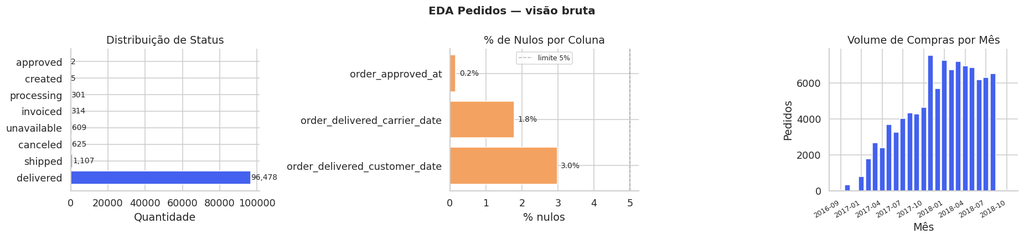

```
Período coberto: 2016-09-04 → 2018-10-17
```

```python
fig, axes = plt.subplots(1, 3, figsize=(17, 4))
fig.suptitle('EDA Pedidos — visão bruta', fontsize=13, fontweight='bold')

# ── Gráfico 1: distribuição de status ──────────────────────────────────────
status_counts = pedidos['order_status'].value_counts()
cores_status  = ['#4361EE' if s == 'delivered' else '#8D99AE'
                 for s in status_counts.index]
axes[0].barh(status_counts.index, status_counts.values,
             color=cores_status, edgecolor='white')
axes[0].set_title('Distribuição de Status')
axes[0].set_xlabel('Quantidade')
for i, v in enumerate(status_counts.values):
    axes[0].text(v + 200, i, f'{v:,}', va='center', fontsize=9)

# ── Gráfico 2: nulos por coluna ────────────────────────────────────────────
nulls_pct = (pedidos.isna().sum() / len(pedidos) * 100).sort_values(ascending=False)
nulls_pct  = nulls_pct[nulls_pct > 0]
cores_null = ['#EF233C' if p > 5 else '#F4A261' for p in nulls_pct.values]
bars = axes[1].barh(nulls_pct.index, nulls_pct.values,
                    color=cores_null, edgecolor='white')
axes[1].set_title('% de Nulos por Coluna')
axes[1].set_xlabel('% nulos')
axes[1].axvline(5, color='gray', linewidth=1, linestyle='--', alpha=0.6,
                label='limite 5%')
axes[1].legend(fontsize=8)
for b, v in zip(bars, nulls_pct.values):
    axes[1].text(v + 0.1, b.get_y() + b.get_height()/2,
                 f'{v:.1f}%', va='center', fontsize=9)

# ── Gráfico 3: volume de compras por mês ───────────────────────────────────
pedidos['mes_compra'] = pedidos['order_purchase_timestamp'].dt.to_period('M')
vol_mes = pedidos.groupby('mes_compra').size()
axes[2].bar(range(len(vol_mes)), vol_mes.values, color='#4361EE', edgecolor='white')
axes[2].set_title('Volume de Compras por Mês')
axes[2].set_xlabel('Mês')
axes[2].set_ylabel('Pedidos')
step = max(1, len(vol_mes) // 8)
axes[2].set_xticks(range(0, len(vol_mes), step))
axes[2].set_xticklabels([str(vol_mes.index[i]) for i in range(0, len(vol_mes), step)],
                        rotation=30, ha='right', fontsize=8)

plt.tight_layout()
plt.show()

print(f'Período coberto: {pedidos["order_purchase_timestamp"].min().date()} → '
      f'{pedidos["order_purchase_timestamp"].max().date()}')
```

### 1.4 Limpeza

- Filtramos apenas pedidos entregues -> order_status == 'delivered' (avaliação válida)
- Remover pedidos sem entrega -> order_delivered_customer_date notna Impossível calcular SLA sem essa data. Deduplicar → drop_duplicates('order_id') Pedidos duplicados distorceriam métricas.

```python
# Passo 1: apenas entregues
print(f'Antes da limpeza                     : {len(pedidos):,}')
pedidos = pedidos[pedidos['order_status'] == 'delivered'].copy()
print(f'Após filtro delivered                : {len(pedidos):,}')

# Passo 2: tem data de entrega real
pedidos = pedidos[pedidos['order_delivered_customer_date'].notna()].copy()
print(f'Após remover sem data de entrega     : {len(pedidos):,}')

# Passo 3: dedup
antes = len(pedidos)
pedidos = pedidos.drop_duplicates('order_id').reset_index(drop=True)
print(f'Após dedup (removidos {antes - len(pedidos):,} dups)        : {len(pedidos):,}')

print(f'\nPedidos limpos: {len(pedidos):,} linhas')
```

```
Antes da limpeza                     : 99,441
Após filtro delivered                : 96,478
Após remover sem data de entrega     : 96,470
Após dedup (removidos 0 dups)        : 96,470

Pedidos limpos: 96,470 linhas
```

### 1.5 Feature derivada — `dias_atraso`

```
dias_atraso = data_entrega_real − data_entrega_estimada
```

- **Negativo** -> chegou **antes** do prazo (frequente)
- **Zero** -> entregue exatamente no prazo
- **Positivo** -> chegou **atrasado**

Esta feature é usada apenas na **análise exploratória** desta etapa para evidenciar a relação entre atraso de entrega e nota de avaliação.

```python
pedidos['dias_atraso'] = (
    pedidos['order_delivered_customer_date'] - pedidos['order_estimated_delivery_date']
).dt.days

pedidos['atrasado'] = (pedidos['dias_atraso'] > 0).astype('boolean')

print('dias_atraso — estatísticas:')
print(pedidos['dias_atraso'].describe().round(1).to_string())
print()
print(f'Pedidos atrasados  : {pedidos["atrasado"].sum():,} ({pedidos["atrasado"].mean():.1%})')
print(f'Pedidos no prazo   : {(~pedidos["atrasado"]).sum():,} ({(~pedidos["atrasado"]).mean():.1%})')
```

```
dias_atraso — estatísticas:
count    96470.0
mean       -11.9
std         10.2
min       -147.0
25%        -17.0
50%        -12.0
75%         -7.0
max        188.0

Pedidos atrasados  : 6,534 (6.8%)
Pedidos no prazo   : 89,936 (93.2%)
```

### 1.6 EDA — após limpeza

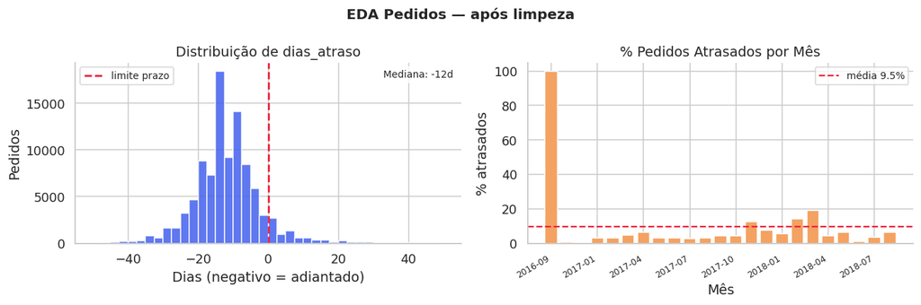

```python
fig, axes = plt.subplots(1, 2, figsize=(12, 4))
fig.suptitle('EDA Pedidos — após limpeza', fontsize=13, fontweight='bold')

# ── Gráfico 1: histograma de dias_atraso ───────────────────────────────────
ax = axes[0]
dentro = pedidos['dias_atraso'][pedidos['dias_atraso'].between(-50, 50)]
ax.hist(dentro, bins=40, color='#4361EE', edgecolor='white', alpha=0.85)
ax.axvline(0, color='#EF233C', linewidth=1.8, linestyle='--', label='limite prazo')
ax.set_title('Distribuição de dias_atraso')
ax.set_xlabel('Dias (negativo = adiantado)')
ax.set_ylabel('Pedidos')
ax.legend(fontsize=9)
ax.text(0.98, 0.96,
        f'Mediana: {pedidos["dias_atraso"].median():.0f}d',
        transform=ax.transAxes, ha='right', va='top', fontsize=9,
        bbox=dict(boxstyle='round,pad=0.3', fc='white', alpha=0.8))

# ── Gráfico 2: % atrasados por mês ─────────────────────────────────────────
ax = axes[1]
pedidos['mes'] = pedidos['order_purchase_timestamp'].dt.to_period('M')
taxa_atraso = pedidos.groupby('mes')['atrasado'].mean() * 100
ax.bar(range(len(taxa_atraso)), taxa_atraso.values,
       color='#F4A261', edgecolor='white')
ax.axhline(taxa_atraso.mean(), color='#EF233C', linewidth=1.5,
           linestyle='--', label=f'média {taxa_atraso.mean():.1f}%')
ax.set_title('% Pedidos Atrasados por Mês')
ax.set_xlabel('Mês')
ax.set_ylabel('% atrasados')
ax.legend(fontsize=9)
step2 = max(1, len(taxa_atraso) // 7)
ax.set_xticks(range(0, len(taxa_atraso), step2))
ax.set_xticklabels([str(taxa_atraso.index[i]) for i in range(0, len(taxa_atraso), step2)],
                   rotation=30, ha='right', fontsize=8)

plt.tight_layout()
plt.show()
```

```python
# Resumo final da tabela pedidos
print('── Schema final pedidos ──────────────────────────')
print(pedidos.dtypes.to_string())
print()
print(f'Linhas: {len(pedidos):,} | Colunas: {pedidos.shape[1]}')
print()
print('── Amostra ──')
pedidos[['order_id','order_purchase_timestamp','order_delivered_customer_date',
     'order_estimated_delivery_date','dias_atraso','atrasado']].head(4)
```

```
── Schema final pedidos ──────────────────────────
order_id                         string[python]
customer_id                      string[python]
order_status                           category
order_purchase_timestamp         datetime64[ns]
order_approved_at                datetime64[ns]
order_delivered_carrier_date     datetime64[ns]
order_delivered_customer_date    datetime64[ns]
order_estimated_delivery_date    datetime64[ns]
mes_compra                            period[M]
dias_atraso                               int64
atrasado                                boolean
mes                                   period[M]

Linhas: 96,470 | Colunas: 12

── Amostra ──
```

|  | order_id | order_purchase_timestamp | order_delivered_customer_date | order_estimated_delivery_date | dias_atraso | atrasado |
| --- | --- | --- | --- | --- | --- | --- |
| 0 | e481f51cbdc54678b7cc49136f2d6af7 | 2017-10-02 10:56:33 | 2017-10-10 21:25:13 | 2017-10-18 | -8 | False |
| 1 | 53cdb2fc8bc7dce0b6741e2150273451 | 2018-07-24 20:41:37 | 2018-08-07 15:27:45 | 2018-08-13 | -6 | False |
| 2 | 47770eb9100c2d0c44946d9cf07ec65d | 2018-08-08 08:38:49 | 2018-08-17 18:06:29 | 2018-09-04 | -18 | False |
| 3 | 949d5b44dbf5de918fe9c16f97b45f8a | 2017-11-18 19:28:06 | 2017-12-02 00:28:42 | 2017-12-15 | -13 | False |

## 2. `avaliacoes.csv`

Contém notas (1–5) e comentários de texto dos clientes, além das datas de criação e resposta da avaliação.

### 2.1 Carga e inspeção inicial

```python
avaliacoes = pd.read_csv(PATH_AVALIACOES)

print(f'Shape   : {avaliacoes.shape}')
print(f'Linhas  : {len(avaliacoes):,}')
print()
print('── Dtypes (antes do tratamento) ──')
print(avaliacoes.dtypes.to_string())
print()
print('── Nulls por coluna ──')
nulls_av = avaliacoes.isna().sum()
pct_av   = (nulls_av / len(avaliacoes) * 100).round(2)
print(pd.DataFrame({'nulos': nulls_av, '%': pct_av}).to_string())
print()
print(f'Duplicatas em review_id: {avaliacoes.duplicated("review_id").sum():,}')
```

```
Shape   : (99224, 7)
Linhas  : 99,224

── Dtypes (antes do tratamento) ──
review_id                  object
order_id                   object
review_score                int64
review_comment_title       object
review_comment_message     object
review_creation_date       object
review_answer_timestamp    object

── Nulls por coluna ──
                         nulos      %
review_id                    0   0.00
order_id                     0   0.00
review_score                 0   0.00
review_comment_title     87656  88.34
review_comment_message   58247  58.70
review_creation_date         0   0.00
review_answer_timestamp      0   0.00

Duplicatas em review_id: 814
```

```python
avaliacoes.head(5)
```

|  | review_id | order_id | review_score | review_comment_title | review_comment_message | review_creation_date | review_answer_timestamp |
| --- | --- | --- | --- | --- | --- | --- | --- |
| 0 | 7bc2406110b926393aa56f80a40eba40 | 73fc7af87114b39712e6da79b0a377eb | 4 | NaN | NaN | 2018-01-18 00:00:00 | 2018-01-18 21:46:59 |
| 1 | 80e641a11e56f04c1ad469d5645fdfde | a548910a1c6147796b98fdf73dbeba33 | 5 | NaN | NaN | 2018-03-10 00:00:00 | 2018-03-11 03:05:13 |
| 2 | 228ce5500dc1d8e020d8d1322874b6f0 | f9e4b658b201a9f2ecdecbb34bed034b | 5 | NaN | NaN | 2018-02-17 00:00:00 | 2018-02-18 14:36:24 |
| 3 | e64fb393e7b32834bb789ff8bb30750e | 658677c97b385a9be170737859d3511b | 5 | NaN | Recebi bem antes do prazo estipulado. | 2017-04-21 00:00:00 | 2017-04-21 22:02:06 |
| 4 | f7c4243c7fe1938f181bec41a392bdeb | 8e6bfb81e283fa7e4f11123a3fb894f1 | 5 | NaN | Parabéns lojas lannister adorei comprar pela I... | 2018-03-01 00:00:00 | 2018-03-02 10:26:53 |

### 2.2 Tipagem

Datas de criação e resposta chegam como `object`. `review_score` já é `int64` (correto).

```python
avaliacoes = avaliacoes.copy()

# ── IDs: StringDtype — identificadores, não valores numéricos ───────────────
for col in ['review_id', 'order_id']:
    avaliacoes[col] = avaliacoes[col].astype('string')

# ── Categórico ordenado: review_score tem hierarquia (1 < 2 < 3 < 4 < 5) ───
avaliacoes['review_score'] = pd.Categorical(
    avaliacoes['review_score'], categories=[1,2,3,4,5], ordered=True
)

# ── Datas ───────────────────────────────────────────────────────────────────
for col in ['review_creation_date', 'review_answer_timestamp']:
    avaliacoes[col] = pd.to_datetime(avaliacoes[col], errors='coerce')

print('── Dtypes após tipagem ──')
print(avaliacoes.dtypes.to_string())
```

```
── Dtypes após tipagem ──
review_id                  string[python]
order_id                   string[python]
review_score                     category
review_comment_title               object
review_comment_message             object
review_creation_date       datetime64[ns]
review_answer_timestamp    datetime64[ns]
```

### Feature derivada: flag booleana — tem comentário de texto?

```python
avaliacoes['tem_comentario'] = avaliacoes['review_comment_message'].notna().astype('boolean')
avaliacoes
```

|  | review_id | order_id | review_score | review_comment_title | review_comment_message | review_creation_date | review_answer_timestamp | tem_comentario |
| --- | --- | --- | --- | --- | --- | --- | --- | --- |
| 0 | 7bc2406110b926393aa56f80a40eba40 | 73fc7af87114b39712e6da79b0a377eb | 4 | NaN | NaN | 2018-01-18 | 2018-01-18 21:46:59 | False |
| 1 | 80e641a11e56f04c1ad469d5645fdfde | a548910a1c6147796b98fdf73dbeba33 | 5 | NaN | NaN | 2018-03-10 | 2018-03-11 03:05:13 | False |
| 2 | 228ce5500dc1d8e020d8d1322874b6f0 | f9e4b658b201a9f2ecdecbb34bed034b | 5 | NaN | NaN | 2018-02-17 | 2018-02-18 14:36:24 | False |
| 3 | e64fb393e7b32834bb789ff8bb30750e | 658677c97b385a9be170737859d3511b | 5 | NaN | Recebi bem antes do prazo estipulado. | 2017-04-21 | 2017-04-21 22:02:06 | True |
| 4 | f7c4243c7fe1938f181bec41a392bdeb | 8e6bfb81e283fa7e4f11123a3fb894f1 | 5 | NaN | Parabéns lojas lannister adorei comprar pela I... | 2018-03-01 | 2018-03-02 10:26:53 | True |
| ... | ... | ... | ... | ... | ... | ... | ... | ... |
| 99219 | 574ed12dd733e5fa530cfd4bbf39d7c9 | 2a8c23fee101d4d5662fa670396eb8da | 5 | NaN | NaN | 2018-07-07 | 2018-07-14 17:18:30 | False |
| 99220 | f3897127253a9592a73be9bdfdf4ed7a | 22ec9f0669f784db00fa86d035cf8602 | 5 | NaN | NaN | 2017-12-09 | 2017-12-11 20:06:42 | False |
| 99221 | b3de70c89b1510c4cd3d0649fd302472 | 55d4004744368f5571d1f590031933e4 | 5 | NaN | Excelente mochila, entrega super rápida. Super... | 2018-03-22 | 2018-03-23 09:10:43 | True |
| 99222 | 1adeb9d84d72fe4e337617733eb85149 | 7725825d039fc1f0ceb7635e3f7d9206 | 4 | NaN | NaN | 2018-07-01 | 2018-07-02 12:59:13 | False |
| 99223 | efe49f1d6f951dd88b51e6ccd4cc548f | 90531360ecb1eec2a1fbb265a0db0508 | 1 | NaN | meu produto chegou e ja tenho que devolver, po... | 2017-07-03 | 2017-07-03 21:01:49 | True |

99224 rows × 8 columns

### 2.3 EDA — visão geral antes da limpeza

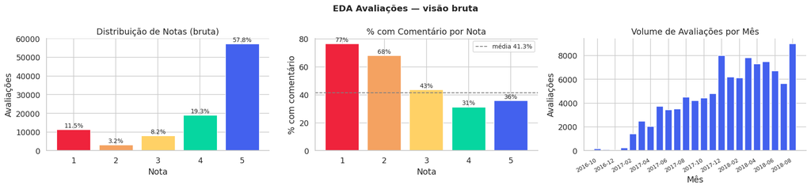

```
Nota mais frequente : 5 (57.8% do total)
Clientes que comentam: 41.3% do total
```

```python
fig, axes = plt.subplots(1, 3, figsize=(17, 4))
fig.suptitle('EDA Avaliações — visão bruta', fontsize=13, fontweight='bold')

# ── Gráfico 1: distribuição de notas ──────────────────────────────────────
ax = axes[0]
score_dist = avaliacoes['review_score'].value_counts().sort_index()
bars = ax.bar(score_dist.index.astype(int), score_dist.values,
              color=PAL_5, edgecolor='white', linewidth=0.8)
ax.set_title('Distribuição de Notas (bruta)')
ax.set_xlabel('Nota')
ax.set_ylabel('Avaliações')
ax.set_xticks([1,2,3,4,5])
for b in bars:
    pct = b.get_height() / len(avaliacoes) * 100
    ax.text(b.get_x() + b.get_width()/2, b.get_height() + 300,
            f'{pct:.1f}%', ha='center', va='bottom', fontsize=9)

# ── Gráfico 2: cobertura de comentários por nota ───────────────────────────
ax = axes[1]
cobertura = (avaliacoes.groupby('review_score', observed=True)['tem_comentario']
               .mean() * 100)
bars2 = ax.bar(cobertura.index.astype(int), cobertura.values,
               color=PAL_5, edgecolor='white')
ax.set_title('% com Comentário por Nota')
ax.set_xlabel('Nota')
ax.set_ylabel('% com comentário')
ax.set_xticks([1,2,3,4,5])
ax.axhline(avaliacoes['tem_comentario'].mean()*100, color='gray',
           linewidth=1.2, linestyle='--',
           label=f'média {avaliacoes["tem_comentario"].mean()*100:.1f}%')
ax.legend(fontsize=9)
for b, v in zip(bars2, cobertura.values):
    ax.text(b.get_x() + b.get_width()/2, v + 0.5,
            f'{v:.0f}%', ha='center', va='bottom', fontsize=9)

# ── Gráfico 3: volume de avaliações por mês ────────────────────────────────
ax = axes[2]
avaliacoes['mes_av'] = avaliacoes['review_creation_date'].dt.to_period('M')
vol_av = avaliacoes.groupby('mes_av').size()
ax.bar(range(len(vol_av)), vol_av.values, color='#4361EE', edgecolor='white')
ax.set_title('Volume de Avaliações por Mês')
ax.set_xlabel('Mês')
ax.set_ylabel('Avaliações')
step3 = max(1, len(vol_av) // 8)
ax.set_xticks(range(0, len(vol_av), step3))
ax.set_xticklabels([str(vol_av.index[i]) for i in range(0, len(vol_av), step3)],
                   rotation=30, ha='right', fontsize=8)

plt.tight_layout()
plt.show()

print(f'Nota mais frequente : {score_dist.idxmax()} ({score_dist.max()/len(avaliacoes):.1%} do total)')
print(f'Clientes que comentam: {avaliacoes["tem_comentario"].mean():.1%} do total')
```

### 2.4 Limpeza

| Passo | Critério | Motivo |
| --- | --- | --- |
| Deduplicar | `drop_duplicates('review_id')` | Havia 814 review_id duplicados |
| Validar score | `review_score ∈ [1, 5]` | Sanidade do target |

> `review_comment_message` **não** é filtrado aqui — mantemos avaliações sem comentário porque a EDA e o join precisam delas. O filtro para o modelo fica no notebook de modelagem.

```python
# Dedup
antes = len(avaliacoes)
avaliacoes = avaliacoes.drop_duplicates('review_id').reset_index(drop=True)
print(f'Removidas {antes - len(avaliacoes):,} linhas duplicadas por review_id')
print(f'Após dedup  : {len(avaliacoes):,}')

# Validar score
avaliacoes = avaliacoes[avaliacoes['review_score'].isin([1,2,3,4,5])].copy()
print(f'Após validar score [1-5] : {len(avaliacoes):,}')

print(f'\nAvaliações limpas: {len(avaliacoes):,} linhas')
```

```
Removidas 814 linhas duplicadas por review_id
Após dedup  : 98,410
Após validar score [1-5] : 98,410

Avaliações limpas: 98,410 linhas
```

### 2.5 Feature derivada — `horas_resposta`

Tempo entre o cliente criar a avaliação e a loja/plataforma responder.  
Medido em horas (float).

```python
avaliacoes['horas_resposta'] = (
    avaliacoes['review_answer_timestamp'] - avaliacoes['review_creation_date']
).dt.total_seconds() / 3600

print('horas_resposta — estatísticas:')
print(avaliacoes['horas_resposta'].describe().round(1).to_string())
print()

# Classifica velocidade de resposta
bins   = [0, 24, 48, 120, float('inf')]
labels = ['< 1 dia', '1–2 dias', '2–5 dias', '> 5 dias']
avaliacoes['velocidade_resposta'] = pd.cut(avaliacoes['horas_resposta'], bins=bins, labels=labels)
print('Distribuição de velocidade_resposta:')
print(avaliacoes['velocidade_resposta'].value_counts().to_string())
```

```
horas_resposta — estatísticas:
count    98410.0
mean        75.6
std        238.0
min          2.1
25%         24.1
50%         40.2
75%         74.4
max      12448.8

Distribuição de velocidade_resposta:
velocidade_resposta
2–5 dias    34262
1–2 dias    30737
< 1 dia     24191
> 5 dias     9220
```

### 2.6 EDA — após limpeza

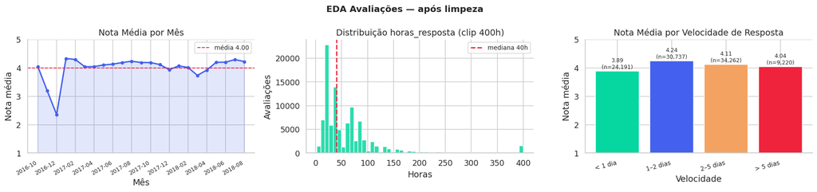

```python
fig, axes = plt.subplots(1, 3, figsize=(17, 4))
fig.suptitle('EDA Avaliações — após limpeza', fontsize=13, fontweight='bold')

# ── Gráfico 1: nota média por mês ─────────────────────────────────────────
ax = axes[0]
avaliacoes['review_score'] = pd.to_numeric(avaliacoes['review_score'], errors='coerce')
avaliacoes['mes_av'] = avaliacoes['review_creation_date'].dt.to_period('M')
nota_mes = avaliacoes.groupby('mes_av')['review_score'].mean()
ax.plot(range(len(nota_mes)), nota_mes.values,
        color='#4361EE', linewidth=2, marker='o', markersize=4)
ax.fill_between(range(len(nota_mes)), nota_mes.values, alpha=0.15, color='#4361EE')
ax.axhline(nota_mes.mean(), color='#EF233C', linewidth=1.2, linestyle='--',
           label=f'média {nota_mes.mean():.2f}')
ax.set_title('Nota Média por Mês')
ax.set_xlabel('Mês')
ax.set_ylabel('Nota média')
ax.set_ylim(1, 5)
ax.legend(fontsize=9)
step4 = max(1, len(nota_mes) // 8)
ax.set_xticks(range(0, len(nota_mes), step4))
ax.set_xticklabels([str(nota_mes.index[i]) for i in range(0, len(nota_mes), step4)],
                   rotation=30, ha='right', fontsize=8)

# ── Gráfico 2: distribuição horas_resposta (clip 400h) ────────────────────
ax = axes[1]
hr_clip = avaliacoes['horas_resposta'].clip(0, 400)
ax.hist(hr_clip, bins=50, color='#06D6A0', edgecolor='white', alpha=0.85)
ax.axvline(avaliacoes['horas_resposta'].median(), color='#EF233C', linewidth=1.8,
           linestyle='--', label=f'mediana {avaliacoes["horas_resposta"].median():.0f}h')
ax.set_title('Distribuição horas_resposta (clip 400h)')
ax.set_xlabel('Horas')
ax.set_ylabel('Avaliações')
ax.legend(fontsize=9)

# ── Gráfico 3: nota média por velocidade de resposta ─────────────────────
ax = axes[2]
ordem = ['< 1 dia', '1–2 dias', '2–5 dias', '> 5 dias']
nota_veloc = (avaliacoes.groupby('velocidade_resposta', observed=True)['review_score']
                .agg(['mean','count'])
                .reindex(ordem))
cores_veloc = ['#06D6A0','#4361EE','#F4A261','#EF233C']
bars3 = ax.bar(range(len(ordem)), nota_veloc['mean'],
               color=cores_veloc, edgecolor='white')
ax.set_title('Nota Média por Velocidade de Resposta')
ax.set_xlabel('Velocidade')
ax.set_ylabel('Nota média')
ax.set_ylim(1, 5)
ax.set_xticks(range(len(ordem)))
ax.set_xticklabels(ordem, rotation=15, ha='right', fontsize=9)
for b, (_, row) in zip(bars3, nota_veloc.iterrows()):
    ax.text(b.get_x() + b.get_width()/2, b.get_height() + 0.04,
            f'{row["mean"]:.2f}\n(n={row["count"]:,.0f})',
            ha='center', va='bottom', fontsize=8)

plt.tight_layout()
plt.show()
```

```python
# Resumo final da tabela avaliações
print(' Schema final avaliações ')
print(avaliacoes.dtypes.to_string())
print()
print(f'Linhas: {len(avaliacoes):,} | Colunas: {avaliacoes.shape[1]}')
print()
print(' Amostra ')
avaliacoes[['review_id','order_id','review_score','tem_comentario',
    'horas_resposta','velocidade_resposta']].head(4)
```

```
 Schema final avaliações
review_id                  string[python]
order_id                   string[python]
review_score                        int64
review_comment_title               object
review_comment_message             object
review_creation_date       datetime64[ns]
review_answer_timestamp    datetime64[ns]
tem_comentario                    boolean
mes_av                          period[M]
horas_resposta                    float64
velocidade_resposta              category

Linhas: 98,410 | Colunas: 11

 Amostra
```

|  | review_id | order_id | review_score | tem_comentario | horas_resposta | velocidade_resposta |
| --- | --- | --- | --- | --- | --- | --- |
| 0 | 7bc2406110b926393aa56f80a40eba40 | 73fc7af87114b39712e6da79b0a377eb | 4 | False | 21.783056 | < 1 dia |
| 1 | 80e641a11e56f04c1ad469d5645fdfde | a548910a1c6147796b98fdf73dbeba33 | 5 | False | 27.086944 | 1–2 dias |
| 2 | 228ce5500dc1d8e020d8d1322874b6f0 | f9e4b658b201a9f2ecdecbb34bed034b | 5 | False | 38.606667 | 1–2 dias |
| 3 | e64fb393e7b32834bb789ff8bb30750e | 658677c97b385a9be170737859d3511b | 5 | True | 22.035000 | < 1 dia |

## 3. Join final — `avaliações e pedidos`

**Inner join** por `order_id`: mantém apenas pedidos entregues que possuem avaliação (e vice-versa).  
Registros sem par em uma das tabelas são descartados.

### 3.1 Merge

```python
df = avaliacoes.merge(
    pedidos,
    on='order_id',
    how='inner',
    suffixes=('_av', '_ped')
)

print(f'avaliações (limpas) : {len(avaliacoes):,}')
print(f'pedidos    (limpos) : {len(pedidos):,}')
print(f'join inner          : {len(df):,}  ({len(df)/len(avaliacoes):.1%} das avaliações encontraram pedido entregue)')
print()
print('── Colunas do dataset final ──')
for col in df.columns:
    print(f'  {col:<36} {str(df[col].dtype):<15}')
```

```
avaliações (limpas) : 98,410
pedidos    (limpos) : 96,470
join inner          : 95,601  (97.1% das avaliações encontraram pedido entregue)

── Colunas do dataset final ──
  review_id                            string
  order_id                             string
  review_score                         int64
  review_comment_title                 object
  review_comment_message               object
  review_creation_date                 datetime64[ns]
  review_answer_timestamp              datetime64[ns]
  tem_comentario                       boolean
  mes_av                               period[M]
  horas_resposta                       float64
  velocidade_resposta                  category
  customer_id                          string
  order_status                         category
  order_purchase_timestamp             datetime64[ns]
  order_approved_at                    datetime64[ns]
  order_delivered_carrier_date         datetime64[ns]
  order_delivered_customer_date        datetime64[ns]
  order_estimated_delivery_date        datetime64[ns]
  mes_compra                           period[M]
  dias_atraso                          int64
  atrasado                             boolean
  mes                                  period[M]
```

### 3.2 EDA cruzada — entrega × satisfação

Investigamos a relação entre o comportamento de entrega (atraso, SLA) e a nota dada pelo cliente.

```python
# Score médio por grupo de atraso
bins_at   = [-float('inf'), -1, 0, 7, 30, float('inf')]
labs_at   = ['Adiantado', 'No prazo', '1–7d atraso', '8–30d atraso', '>30d atraso']
df['grupo_atraso'] = pd.Categorical(
    pd.cut(df['dias_atraso'], bins=bins_at, labels=labs_at),
    categories=labs_at, ordered=True
)

score_grupo = (df.groupby('grupo_atraso', observed=True)['review_score']
                 .agg(['mean','count','std'])
                 .round(2))

print('Nota média por grupo de atraso:')
print(score_grupo.to_string())
print()
print(f'Correlação (Pearson) dias_atraso × review_score: '
      f'{df[["dias_atraso","review_score"]].corr().iloc[0,1]:+.3f}')
```

```
Nota média por grupo de atraso:
              mean  count   std
grupo_atraso
Adiantado     4.30  87969  1.15
No prazo      4.04   1271  1.25
1–7d atraso   2.72   3589  1.66
8–30d atraso  1.65   2444  1.18
>30d atraso   2.05    328  1.52

Correlação (Pearson) dias_atraso × review_score: -0.268
```

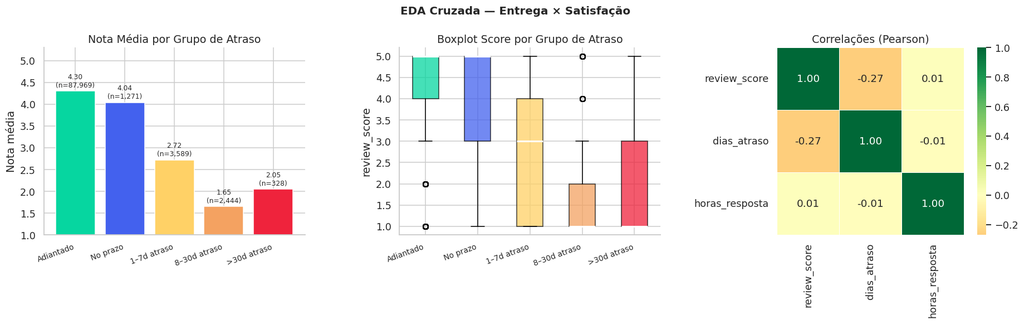

```python
fig, axes = plt.subplots(1, 3, figsize=(17, 5))
fig.suptitle('EDA Cruzada — Entrega × Satisfação', fontsize=13, fontweight='bold')

# ── Gráfico 1: nota média por grupo de atraso ─────────────────────────────
ax = axes[0]
cores_at = ['#06D6A0','#4361EE','#FFD166','#F4A261','#EF233C']
bars_at  = ax.bar(range(len(score_grupo)), score_grupo['mean'],
                  color=cores_at, edgecolor='white')
ax.set_xticks(range(len(score_grupo)))
ax.set_xticklabels(score_grupo.index, rotation=20, ha='right', fontsize=9)
ax.set_title('Nota Média por Grupo de Atraso')
ax.set_ylabel('Nota média')
ax.set_ylim(1, 5.3)
for b, (_, row) in zip(bars_at, score_grupo.iterrows()):
    ax.text(b.get_x() + b.get_width()/2, b.get_height() + 0.05,
            f'{row["mean"]:.2f}\n(n={row["count"]:,.0f})',
            ha='center', va='bottom', fontsize=8)

# ── Gráfico 2: boxplot score × grupo de atraso ────────────────────────────
ax = axes[1]
data_bx = [df[df['grupo_atraso'] == g]['review_score'].astype(float).values
           for g in labs_at]
bp2 = ax.boxplot(data_bx, patch_artist=True,
                 medianprops=dict(color='white', linewidth=2))
for patch, cor in zip(bp2['boxes'], cores_at):
    patch.set_facecolor(cor)
    patch.set_alpha(0.75)
ax.set_xticks(range(1, len(labs_at)+1))
ax.set_xticklabels(labs_at, rotation=20, ha='right', fontsize=9)
ax.set_title('Boxplot Score por Grupo de Atraso')
ax.set_ylabel('review_score')

# ── Gráfico 3: heatmap de correlações numéricas ───────────────────────────
ax = axes[2]
num_cols = ['review_score','dias_atraso','horas_resposta']
df_num   = df[num_cols].copy()
df_num['review_score'] = df_num['review_score'].astype(float)
corr_mat = df_num.corr().round(2)
mask     = np.zeros_like(corr_mat, dtype=bool)
mask[np.triu_indices_from(mask, k=1)] = True
sns.heatmap(corr_mat, ax=ax, annot=True, fmt='.2f',
            cmap='RdYlGn', center=0, linewidths=0.5,
            annot_kws={'size': 12}, square=True)
ax.set_title('Correlações (Pearson)')

plt.tight_layout()
plt.show()
```

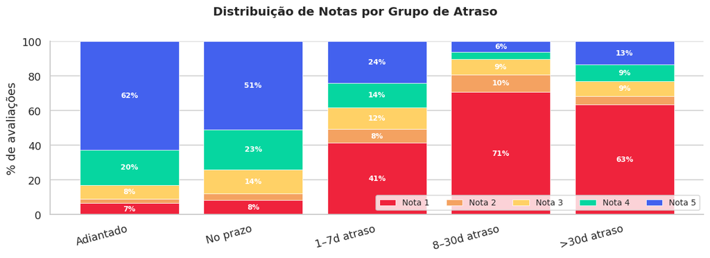

```python
# Proporção de notas por grupo de atraso (stacked bar)
fig, ax = plt.subplots(figsize=(11, 4))
fig.suptitle('Distribuição de Notas por Grupo de Atraso', fontsize=13, fontweight='bold')

prop = (df.groupby(['grupo_atraso','review_score'], observed=True)
          .size()
          .unstack('review_score')
          .fillna(0))
prop_pct = prop.div(prop.sum(axis=1), axis=0) * 100

bottom = np.zeros(len(prop_pct))
for nota, cor in zip([1,2,3,4,5], PAL_5):
    if nota in prop_pct.columns:
        vals = prop_pct[nota].values
        ax.bar(range(len(prop_pct)), vals, bottom=bottom,
               label=f'Nota {nota}', color=cor, edgecolor='white', linewidth=0.5)
        for i, (v, b) in enumerate(zip(vals, bottom)):
            if v > 6:
                ax.text(i, b + v/2, f'{v:.0f}%', ha='center', va='center',
                        fontsize=8, color='white', fontweight='bold')
        bottom += vals

ax.set_xticks(range(len(prop_pct)))
ax.set_xticklabels(prop_pct.index, rotation=15, ha='right')
ax.set_ylabel('% de avaliações')
ax.set_ylim(0, 100)
ax.legend(loc='lower right', ncol=5, fontsize=9)
plt.tight_layout()
plt.show()
```

### 3.3 Schema e qualidade final do dataset

```python
print('── Schema final do dataset consolidado ───────────────────────────────────')
info = pd.DataFrame({
    'dtype'   : df.dtypes,
    'nulos'   : df.isna().sum(),
    '% nulos' : (df.isna().sum() / len(df) * 100).round(2),
    'únicos'  : df.nunique(),
})
print(info.to_string())
print()
print(f'Linhas  : {len(df):,}')
print(f'Colunas : {df.shape[1]}')
```

```
── Schema final do dataset consolidado ───────────────────────────────────
                                        dtype  nulos  % nulos  únicos
review_id                      string[python]      0     0.00   95601
order_id                       string[python]      0     0.00   95364
review_score                            int64      0     0.00       5
review_comment_title                   object  84431    88.32    4361
review_comment_message                 object  56785    59.40   34415
review_creation_date           datetime64[ns]      0     0.00     627
review_answer_timestamp        datetime64[ns]      0     0.00   95448
tem_comentario                        boolean      0     0.00       2
mes_av                              period[M]      0     0.00      23
horas_resposta                        float64      0     0.00   79853
velocidade_resposta                  category      0     0.00       4
customer_id                    string[python]      0     0.00   95364
order_status                         category      0     0.00       1
order_purchase_timestamp       datetime64[ns]      0     0.00   94998
order_approved_at              datetime64[ns]     14     0.01   87340
order_delivered_carrier_date   datetime64[ns]      1     0.00   79234
order_delivered_customer_date  datetime64[ns]      0     0.00   94569
order_estimated_delivery_date  datetime64[ns]      0     0.00     445
mes_compra                          period[M]      0     0.00      23
dias_atraso                             int64      0     0.00     196
atrasado                              boolean      0     0.00       2
mes                                 period[M]      0     0.00      23
grupo_atraso                         category      0     0.00       5

Linhas  : 95,601
Colunas : 23
```

```python
# Sumário estatístico das colunas numéricas
df_num_final = df[['review_score','dias_atraso','horas_resposta']].copy()
df_num_final['review_score'] = df_num_final['review_score'].astype(float)
print('── Estatísticas descritivas (colunas numéricas-chave) ──')
print(df_num_final.describe().round(2).to_string())
```

```
── Estatísticas descritivas (colunas numéricas-chave) ──
       review_score  dias_atraso  horas_resposta
count      95601.00     95601.00        95601.00
mean           4.16       -11.91           75.52
std            1.28        10.11          235.28
min            1.00      -147.00            2.14
25%            4.00       -17.00           24.29
50%            5.00       -12.00           40.35
75%            5.00        -7.00           74.67
max            5.00       188.00        12448.78
```

### 3.4 Salvamento

Salva o dataset final em CSV para uso nos notebooks de modelagem.

```python
from google.colab import drive
drive.mount('/content/drive', force_remount=True)
```

```python
# Garante que categorias sejam salvas como string
df_save = df.copy()
df_save['review_score']       = df_save['review_score'].astype(int)
df_save['grupo_atraso']       = df_save['grupo_atraso'].astype(str)
df_save['velocidade_resposta']= df_save['velocidade_resposta'].astype(str)
df_save['tem_comentario']     = df_save['tem_comentario'].astype(bool)
df_save['atrasado']           = df_save['atrasado'].astype(bool)

df_save.to_csv(PATH_OUTPUT, index=False)
size_mb = os.path.getsize(PATH_OUTPUT) / 1024**2
print(f'✅ Salvo em: {PATH_OUTPUT}')
print(f'   Tamanho : {size_mb:.1f} MB')
print(f'   Linhas  : {len(df_save):,}')
print(f'   Colunas : {df_save.shape[1]}')
```

```
✅ Salvo em: /content/drive/MyDrive/Projeto Integrador/Banco_de_Dados_PII3_AWS/dataset_tratado.csv
   Tamanho : 31.9 MB
   Linhas  : 95,601
   Colunas : 23
```

## 4. Resumo

### O que foi feito

| Tabela | Bruto | Após limpeza | Removidos | Motivo principal |
| --- | --- | --- | --- | --- |
| `pedidos.csv` | 99.441 | 96.470 | 2.971 | status ≠ delivered + sem data entrega |
| `avaliacoes.csv` | 99.224 | 98.410* | 814 | duplicatas de review_id |
| **Join final** | — | **95.601** | — | inner join por order_id |

*A tabela de avaliações mantém registros sem comentário — filtro para o modelo fica no notebook de modelagem.

### Features derivadas criadas

| Feature | Tabela | Descrição |
| --- | --- | --- |
| `dias_atraso` | pedidos | entrega_real − entrega_estimada (negativo = adiantado) |
| `atrasado` | pedidos | bool — `dias_atraso > 0` |
| `tem_comentario` | avaliacoes | bool — `review_comment_message notna` |
| `horas_resposta` | avaliacoes | horas entre criação e resposta da avaliação |
| `velocidade_resposta` | avaliacoes | categoria: < 1 dia / 1–2 dias / 2–5 dias / > 5 dias |
| `grupo_atraso` | join | categoria: Adiantado / No prazo / 1–7d / 8–30d / >30d |

# ETAPA 2 - Predição de Notas com Regressão Linear em Texto

Continuamos a partir da base tratada salva pelo EDA.  
Carregamos `dataset_tratado.csv` para que essa parte fique independente — pode ser executada sem reexecutar todo o tratamento.

```python
# # Leitura da base tratada salva ao final do EDA
# df = pd.read_csv(PATH_OUTPUT)

# print(f'Base tratada carregada: {len(df):,} linhas | {df.shape[1]} colunas')
# print(f'Colunas: {list(df.columns)}')
# df.head(3)
```

## 📊 Predição de Nota de Avaliação com Regressão Linear em Texto

**Objetivo:** dado o texto livre de um comentário de cliente, estimar a nota (1 a 5) que ele irá atribuir à sua compra.

**Técnica central:** transformamos palavras em números (TF-IDF) e usamos esses números como variáveis explicativas em uma regressão linear. O modelo aprende que certas palavras ("péssimo", "atrasado") puxam a nota para baixo, enquanto outras ("rápido", "perfeito") puxam para cima.

## Estrutura do notebook

[output not shown]

## 1. Imports & Configuração

Todas as bibliotecas necessárias são nativas do ambiente Colab — nenhuma instalação adicional é necessária.

- **pandas / numpy** → manipulação de dados
- **matplotlib / seaborn** → visualizações
- **sklearn** → TF-IDF, Ridge Regression, métricas e pipeline
- **re** → expressões regulares para limpar o texto

```python
import re
import warnings
import numpy as np
import pandas as pd
import matplotlib.pyplot as plt
import matplotlib.gridspec as gridspec
import seaborn as sns

from sklearn.feature_extraction.text import TfidfVectorizer
from sklearn.linear_model import Ridge
from sklearn.model_selection import train_test_split, cross_val_score
from sklearn.metrics import (
    mean_squared_error, mean_absolute_error, r2_score, confusion_matrix
)
from sklearn.pipeline import Pipeline

warnings.filterwarnings("ignore")
%matplotlib inline

print("✅ Imports OK")
```

```
✅ Imports OK
```

```python
# ── Constantes globais ──────────────────────────────────────────────────────
# Altere DATA_PATH se o arquivo estiver em outro local (ex.: Google Drive)
DATA_PATH   = df   # ajuste para o caminho correto no seu ambiente
RANDOM_SEED = 42                 # garante reprodutibilidade
TEST_SIZE   = 0.20               # 20% dos dados para teste

# Paleta de cores dos gráficos
PALETTE = {
    "primary" : "#4361EE",
    "positive": "#06D6A0",
    "negative": "#EF233C",
    "neutral" : "#8D99AE",
    "bg"      : "#F8F9FA",
}
SCORE_COLORS = {1: "#EF233C", 2: "#F4A261", 3: "#FFD166",
                4: "#06D6A0", 5: "#4361EE"}

# Estilo global dos gráficos
plt.rcParams.update({
    "figure.facecolor" : PALETTE["bg"],
    "axes.facecolor"   : PALETTE["bg"],
    "axes.spines.top"  : False,
    "axes.spines.right": False,
    "font.family"      : "sans-serif",
})

print("✅ Configurações OK")
```

```
✅ Configurações OK
```

## 2. Stopwords PT-BR

**Stopwords** são palavras de alta frequência que não carregam significado útil para o modelo (artigos, preposições, pronomes, verbos auxiliares).

Exemplos: *"de", "a", "o", "que", "para", "com"*

Removê-las reduz o ruído e melhora a qualidade das features. Aqui usamos uma lista manual em PT-BR, evitando dependências externas (como o `nltk`).

```python
STOPWORDS_PT = set([
    "de","a","o","que","e","do","da","em","um","para","com","uma","os","no",
    "se","na","por","mais","as","dos","como","mas","ao","ele","das","à","seu",
    "sua","ou","quando","muito","nos","já","eu","também","só","pelo","pela",
    "até","isso","ela","entre","depois","sem","mesmo","aos","seus","quem","nas",
    "me","esse","eles","você","essa","num","nem","suas","meu","às","minha",
    "numa","pelos","elas","seja","qual","será","nós","tenho","lhe","deles",
    "essas","esses","pelas","este","foi","ter","tem","temos","foram","está",
    "tinha","estou","vou","vai","fui","era","ser","não","sim","aqui","ali",
    "lá","então","agora","ainda","aquele","tudo","todo","todos","toda","todas",
    "cada","outro","outra","outros","outras","nada","algo","alguém","ninguém",
    "algum","alguma","alguns","algumas","nenhum","nenhuma","há","la","le","pra",
    "pro","bem","ta","tá","tb","tbm","faz","fazer","feito","ficou","ficei",
    "fique","fica","veio","vem","vir","vão","vim","ver","vi","vejo","so","ja",
    "ne","né","nao","ai","aí","ah","oh","oi","ola",
])

print(f"✅ {len(STOPWORDS_PT)} stopwords carregadas")
```

```
✅ 152 stopwords carregadas
```

### Foi necessário aplicar ajustes para melhorar o desempenho:

```python
NEGACOES = {"não", "nao", "nem", "nunca", "jamais", "sem", "nada", "nenhum", "nenhuma"}
STOPWORDS_PT = STOPWORDS_PT - NEGACOES
```

## 3. Funções Auxiliares

### `clean_text(text)`

Aplica o pipeline de limpeza NLP (processamento de linguagem natural), ao texto bruto:

1. Converte para minúsculas
2. Remove tudo que não for letra (pontuação, números, emojis)
3. Remove espaços duplicados
4. Filtra stopwords e tokens muito curtos (< 3 caracteres)

### `round_to_score(pred)`

Converte a predição contínua (ex.: 3.7) para inteiro mais próximo no intervalo [1, 5].

### `predict_comment(text, pipeline)`

Recebe um texto novo e retorna a nota estimada + as palavras que mais influenciaram a decisão.

```python
def clean_text(text: str) -> str:
    """Normaliza e limpa um comentário em português."""
    if not isinstance(text, str):
        return ""
    text = text.lower()
    text = re.sub(r'[^a-záàâãéèêíïóôõöúüçñ\s]', ' ', text)  # só letras
    text = re.sub(r'\s+', ' ', text).strip()                  # espaços extras
    tokens = [w for w in text.split()
              if w not in STOPWORDS_PT and len(w) > 2]
    return ' '.join(tokens)


def round_to_score(pred: np.ndarray) -> np.ndarray:
    """Arredonda predição contínua para nota inteira em [1, 5]."""
    return np.clip(np.round(pred).astype(int), 1, 5)


def predict_comment(text: str, pipeline) -> dict:
    """Retorna nota estimada e palavras-chave para um comentário novo."""
    text_clean = clean_text(text)
    tfidf_vec  = pipeline.named_steps["tfidf"]
    model      = pipeline.named_steps["ridge"]

    vec     = tfidf_vec.transform([text_clean])
    raw     = model.predict(vec)[0]
    clipped = float(np.clip(raw, 1, 5))
    rounded = int(round_to_score(np.array([clipped]))[0])

    # Contribuição de cada palavra presente no comentário
    feat_names   = tfidf_vec.get_feature_names_out()
    coef         = model.coef_
    nonzero      = vec.nonzero()[1]
    word_weights = sorted(
        [(feat_names[i], coef[i] * vec[0, i]) for i in nonzero],
        key=lambda x: x[1], reverse=True
    )
    return {
        "score_raw"    : round(clipped, 2),
        "score_rounded": rounded,
        "palavras_pos" : [(w, round(float(v), 3)) for w, v in word_weights if v > 0][:5],
        "palavras_neg" : [(w, round(float(v), 3)) for w, v in word_weights if v < 0][:5],
    }


# Teste rápido da limpeza
exemplo = "Produto chegou antes do prazo! Muito bom :)"
print(f"Original : {exemplo}")
print(f"Limpo    : {clean_text(exemplo)}")
```

```
Original : Produto chegou antes do prazo! Muito bom :)
Limpo    : produto chegou antes prazo bom
```

## 4. Carga dos Dados

O dataset `avaliacoes.csv` contém **99.224 avaliações** de clientes.

Colunas relevantes para este projeto:

| Coluna | Tipo | Descrição |
| --- | --- | --- |
| `review_score` | int (1–5) | ⭐ **Target (y)** — nota dada pelo cliente |
| `review_comment_message` | str | 💬 **Input (X)** — texto livre do comentário |
| `review_comment_title` | str | Título opcional (pouco preenchido) |
| `review_creation_date` | str | Data da avaliação |

> ⚠️ **Importante:** apenas ~41% das avaliações têm comentário de texto. O modelo só consegue aprender a partir dessas.

```python
print(f"Total de avaliações  : {len(df):,}")
print(f"Colunas              : {list(df.columns)}")
print(f"Com comentário       : {df['review_comment_message'].notna().sum():,}")
print(f"Sem comentário       : {df['review_comment_message'].isna().sum():,}")

periodo = pd.to_datetime(df['review_creation_date'], errors='coerce')
print(f"Período              : {periodo.min().strftime('%Y-%m-%d')} --> {periodo.max().strftime('%Y-%m-%d')}")
print()
df.head(3)
```

```
Total de avaliações  : 95,601
Colunas              : ['review_id', 'order_id', 'review_score', 'review_comment_title', 'review_comment_message', 'review_creation_date', 'review_answer_timestamp', 'tem_comentario', 'mes_av', 'horas_resposta', 'velocidade_resposta', 'customer_id', 'order_status', 'order_purchase_timestamp', 'order…
Com comentário       : 38,816
Sem comentário       : 56,785
Período              : 2016-10-06 --> 2018-08-31
```

|  | review_id | order_id | review_score | review_comment_title | review_comment_message | review_creation_date | review_answer_timestamp | tem_comentario | mes_av | horas_resposta | ... | order_purchase_timestamp | order_approved_at | order_delivered_carrier_date | order_delivered_customer_date | order_estimated_delivery_date | mes_compra | dias_atraso | atrasado | mes | grupo_atraso |
| --- | --- | --- | --- | --- | --- | --- | --- | --- | --- | --- | --- | --- | --- | --- | --- | --- | --- | --- | --- | --- | --- |
| 0 | 7bc2406110b926393aa56f80a40eba40 | 73fc7af87114b39712e6da79b0a377eb | 4 | NaN | NaN | 2018-01-18 | 2018-01-18 21:46:59 | False | 2018-01 | 21.783056 | ... | 2018-01-11 15:30:49 | 2018-01-11 15:47:59 | 2018-01-12 21:57:22 | 2018-01-17 18:42:41 | 2018-02-02 | 2018-01 | -16 | False | 2018-01 | Adiantado |
| 1 | 80e641a11e56f04c1ad469d5645fdfde | a548910a1c6147796b98fdf73dbeba33 | 5 | NaN | NaN | 2018-03-10 | 2018-03-11 03:05:13 | False | 2018-03 | 27.086944 | ... | 2018-02-28 12:25:19 | 2018-02-28 12:48:39 | 2018-03-02 19:08:15 | 2018-03-09 23:17:20 | 2018-03-14 | 2018-02 | -5 | False | 2018-02 | Adiantado |
| 2 | 228ce5500dc1d8e020d8d1322874b6f0 | f9e4b658b201a9f2ecdecbb34bed034b | 5 | NaN | NaN | 2018-02-17 | 2018-02-18 14:36:24 | False | 2018-02 | 38.606667 | ... | 2018-02-03 09:56:22 | 2018-02-03 10:33:41 | 2018-02-06 16:18:28 | 2018-02-16 17:28:48 | 2018-03-09 | 2018-02 | -21 | False | 2018-02 | Adiantado |

3 rows × 23 columns

## 5. Análise Exploratória (EDA)

Antes de modelar, precisamos entender a distribuição dos dados:

- **Distribuição das notas:** o dataset é fortemente enviesado — a nota 5 representa mais de 57% das avaliações. Isso é um **desafio para o modelo**, pois ele terá mais exemplos de notas altas.
- **Cobertura de comentários:** clientes insatisfeitos (nota 1) comentam proporcionalmente mais do que satisfeitos (nota 5), que frequentemente avaliam sem texto.
- **Tamanho dos comentários:** comentários negativos tendem a ser mais longos — o cliente insatisfeito tem mais a dizer.

```python
score_dist = df["review_score"].value_counts().sort_index()
print("Distribuição de notas:")
print(score_dist.to_string())
print(f"\nNota mais comum: {score_dist.idxmax()} ({score_dist.max()/len(df):.1%} do total)")
```

```
Distribuição de notas:
review_score
1     9291
2     2908
3     7884
4    18861
5    56657

Nota mais comum: 5 (59.3% do total)
```

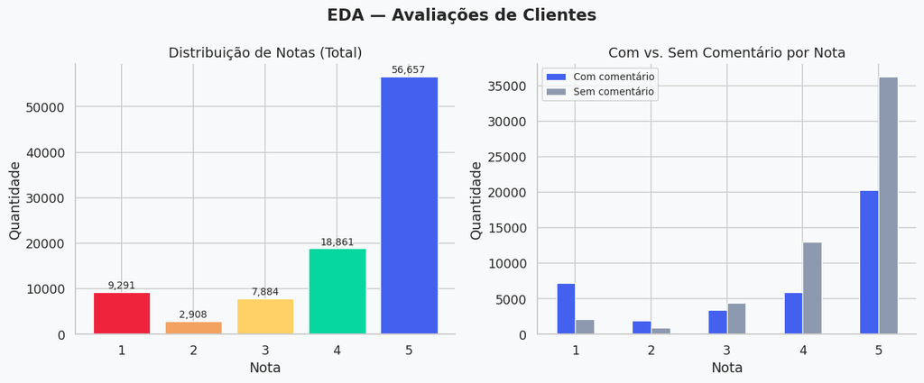

```python
fig, axes = plt.subplots(1, 2, figsize=(12, 5))
fig.suptitle("EDA — Avaliações de Clientes", fontsize=15, fontweight="bold")

# ── Gráfico 1: Distribuição geral das notas ──────────────────────────────────
ax = axes[0]
bars = ax.bar(score_dist.index, score_dist.values,
              color=[SCORE_COLORS[s] for s in score_dist.index],
              edgecolor="white", linewidth=0.8)
ax.set_title("Distribuição de Notas (Total)")
ax.set_xlabel("Nota")
ax.set_ylabel("Quantidade")
ax.set_xticks([1, 2, 3, 4, 5])
for b in bars:
    ax.text(b.get_x() + b.get_width()/2, b.get_height() + 300,
            f"{int(b.get_height()):,}", ha="center", va="bottom", fontsize=9)

# ── Gráfico 2: Com vs. sem comentário por nota ───────────────────────────────
has_comment = df.groupby("review_score")["review_comment_message"].apply(
    lambda x: pd.Series({"Com comentário": x.notna().sum(),
                          "Sem comentário": x.isna().sum()})
).unstack()
has_comment.plot(kind="bar", ax=axes[1],
                 color=[PALETTE["primary"], PALETTE["neutral"]],
                 edgecolor="white", linewidth=0.8, rot=0)
axes[1].set_title("Com vs. Sem Comentário por Nota")
axes[1].set_xlabel("Nota")
axes[1].set_ylabel("Quantidade")
axes[1].legend(fontsize=9)

plt.tight_layout()
plt.show()
```

## 6. Pré-processamento de Texto

Aplicamos a função `clean_text` a todos os comentários e filtramos registros vazios após a limpeza.

**Passos aplicados a cada comentário:**

```
"Produto chegou antes do prazo! Muito bom :)"
        ↓ lower()
"produto chegou antes do prazo! muito bom :)"
        ↓ remove não-letras
"produto chegou antes do prazo  muito bom  "
        ↓ remove stopwords e tokens < 3 chars
"produto chegou antes prazo bom"
```

**Observação interessante:** clientes que deixam notas baixas (1–2) escrevem comentários mais longos em média — eles têm mais a reclamar.

```python
# Filtra apenas linhas com comentário e aplica limpeza
df_model = df[df["review_comment_message"].notna()].copy()
df_model["text_clean"] = df_model["review_comment_message"].apply(clean_text)

# Remove comentários que ficaram vazios após a limpeza
df_model = df_model[df_model["text_clean"].str.len() > 3].reset_index(drop=True)

print(f"Registros após filtro : {len(df_model):,}")
print()
print("Exemplo de limpeza:")
idx = df_model[df_model["review_score"] == 1].index[0]
print(f"  Original : {df_model.loc[idx, 'review_comment_message']}")
print(f"  Limpo    : {df_model.loc[idx, 'text_clean']}")
```

```
Registros após filtro : 37,090

Exemplo de limpeza:
  Original : Não gostei ! Comprei gato por lebre
  Limpo    : não gostei comprei gato lebre
```

```
Média de palavras por nota (após limpeza):
review_score
1    9.9
2    9.6
3    8.5
4    6.5
5    5.5
```

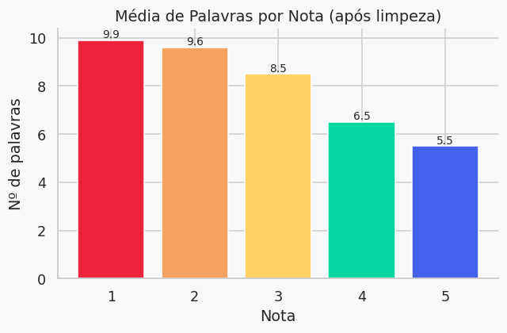

```python
# Contagem de palavras por avaliação (após limpeza)
df_model["word_count"] = df_model["text_clean"].str.split().str.len()
avg_words = df_model.groupby("review_score")["word_count"].mean().round(1)

print("Média de palavras por nota (após limpeza):")
print(avg_words.to_string())

# Atualiza o 3º gráfico da EDA com os dados reais
fig, ax = plt.subplots(figsize=(6, 4))
ax.bar(avg_words.index, avg_words.values,
       color=[SCORE_COLORS[s] for s in avg_words.index],
       edgecolor="white")
ax.set_title("Média de Palavras por Nota (após limpeza)")
ax.set_xlabel("Nota")
ax.set_ylabel("Nº de palavras")
ax.set_xticks([1, 2, 3, 4, 5])
for i, v in zip(avg_words.index, avg_words.values):
    ax.text(i, v + 0.1, f"{v:.1f}", ha="center", fontsize=9)
plt.tight_layout()
plt.show()
```

## 7. Divisão Treino / Teste

Dividimos o dataset em dois conjuntos:

- **Treino (80%):** usado para o modelo aprender os padrões.
- **Teste (20%):** reservado para avaliar o modelo em dados **nunca vistos**.

O parâmetro `stratify=y` garante que a proporção de cada nota seja mantida nos dois conjuntos — essencial quando há desequilíbrio de classes (como aqui, onde nota 5 é muito mais frequente).

[output not shown]

```python
X_train, X_test, y_train, y_test = train_test_split(
    df_model["text_clean"],
    df_model["review_score"],
    test_size=TEST_SIZE,
    random_state=RANDOM_SEED,
    stratify=df_model["review_score"],  # mantém proporção de classes
)

print(f"Treino : {len(X_train):,} amostras")
print(f"Teste  : {len(X_test):,} amostras")
print()
print("Proporção de notas no treino:")
print((y_train.value_counts(normalize=True).sort_index() * 100).round(1).to_string())
```

```
Treino : 29,672 amostras
Teste  : 7,418 amostras

Proporção de notas no treino:
review_score
1    19.3
2     5.3
3     8.8
4    14.8
5    51.8
```

## 8. Vetorização com TF-IDF

**Modelos de Machine Learning não entendem texto — só números.** O TF-IDF converte cada comentário em um vetor numérico.

### O que é TF-IDF?

Para cada palavra em cada documento, calcula dois fatores:

- **TF (Term Frequency):** quão frequente é a palavra *neste* documento.
- **IDF (Inverse Document Frequency):** quão rara ela é *em todos* os documentos — palavras comuns demais recebem peso menor.

```
TF-IDF(palavra, doc) = TF × IDF
```

Resultado: uma matriz esparsa onde cada **linha = comentário** e cada **coluna = palavra (feature)**.

### Parâmetros escolhidos

| Parâmetro | Valor | Por quê |
| --- | --- | --- |
| `max_features` | 8.000 | Limita vocabulário ao top-8k palavras mais informativas |
| `ngram_range=(1,2)` | uni + bigramas | Captura "chegou antes", "produto quebrado" como features únicas |
| `min_df=5` | min 5 docs | Ignora palavras que aparecem em menos de 5 comentários (ruído) |
| `sublinear_tf=True` | log(TF) | Evita que palavras repetidas muitas vezes dominem o vetor |

> 💡 **Bigrama** = sequência de 2 palavras. Ex: "entrega rápida", "não recebi". Capturam contexto que unigramas isolados perderiam.

## 9. Treinamento — Ridge Regression

### Por que Ridge e não Regressão Linear simples?

Com 8.000 features (palavras), a regressão linear padrão (OLS) tende a **overfitting** — ela memoriza padrões do treino que não generalizam.

A **Ridge Regression** adiciona uma penalidade aos coeficientes grandes (regularização L2), forçando o modelo a ser mais "conservador":

```
Regressão Linear:   minimiza  Σ(y - ŷ)²
Ridge:              minimiza  Σ(y - ŷ)²  +  α × Σ(coef²)
                                            ↑ penalidade
```

O parâmetro `α = 1.0` controla a força da regularização. Quanto maior, mais o modelo é "encolhido".

### Pipeline sklearn

Encadeamos TF-IDF + Ridge em um único objeto `Pipeline`. Isso garante que:

1. O vocabulário TF-IDF seja aprendido **apenas** no treino (sem data leakage).
2. A transformação e predição sejam aplicadas consistentemente.

```python
tfidf_vectorizer = TfidfVectorizer(
    max_features=8000,
    ngram_range=(1,2),
    min_df=5,
    sublinear_tf=True
)
ridge_model = Ridge(alpha=1.0)

pipe = Pipeline([('tfidf', tfidf_vectorizer), ('ridge', ridge_model)])

# Fit the pipeline on the training data
pipe.fit(X_train, y_train)

# Refaz o split garantindo alinhamento total
X_train, X_test, y_train, y_test = train_test_split(
    df_model["text_clean"],
    df_model["review_score"],
    test_size=TEST_SIZE,
    random_state=RANDOM_SEED,
    stratify=df_model["review_score"],
)

# Regenera predições com o X_test correto
preds_raw     = pipe.predict(X_test)
preds_clipped = np.clip(preds_raw, 1, 5)
preds_rounded = round_to_score(preds_clipped)

# Confirma alinhamento
assert len(X_test) == len(y_test) == len(preds_clipped), \
    f"Desalinhamento: X_test={len(X_test)}, y_test={len(y_test)}, preds={len(preds_clipped)}"

print(f"✅ Alinhado: {len(y_test)} amostras no teste")
print(f"   X_test       : {X_test.shape}")
print(f"   y_test       : {y_test.shape}")
print(f"   preds_clipped: {preds_clipped.shape}")
```

```
✅ Alinhado: 7418 amostras no teste
   X_test       : (7418,)
   y_test       : (7418,)
   preds_clipped: (7418,)
```

```python
from scipy.stats import pearsonr, spearmanr
from sklearn.metrics import mean_squared_error, mean_absolute_error

# Métricas
rmse = np.sqrt(mean_squared_error(y_test, preds_clipped))
mae  = mean_absolute_error(y_test, preds_clipped)

acc_exact = (preds_rounded == y_test.values).mean()
acc_1off  = (np.abs(preds_rounded - y_test.values) <= 1).mean()

# Correlações
pearson_r,  pearson_p  = pearsonr(y_test, preds_clipped)
spearman_r, spearman_p = spearmanr(y_test, preds_clipped)

print("── Correlações (nota real × nota predita) ─────────────────")
print(f"  Pearson  r = {pearson_r:.4f}  (p = {pearson_p:.2e})")
print(f"  Spearman ρ = {spearman_r:.4f}  (p = {spearman_p:.2e})")
print()
print(f"  RMSE = {rmse:.4f}")
print(f"  MAE  = {mae:.4f}")
print()
print("── Classificação (nota arredondada) ───────────────────────")
print(f"  Acurácia exata : {acc_exact:.2%}")
print(f"  Acurácia ±1    : {acc_1off:.2%}")
```

```
── Correlações (nota real × nota predita) ─────────────────
  Pearson  r = 0.8209  (p = 0.00e+00)
  Spearman ρ = 0.7485  (p = 0.00e+00)

  RMSE = 0.9020
  MAE  = 0.6359

── Classificação (nota arredondada) ───────────────────────
  Acurácia exata : 53.46%
  Acurácia ±1    : 89.30%
```

```python
# ── Cross-Validation (5-fold)
# Avalia o modelo em 5 subconjuntos diferentes para checar estabilidade.
# Se R² do CV for próximo ao R² do teste, o modelo NÃO sofre de overfitting.

cv_r2 = cross_val_score(
    pipe,
    df_model["text_clean"],
    df_model["review_score"],
    cv=5,
    scoring="r2",
    n_jobs=-1
)

print(f"R² Cross-Validation (5-fold): {cv_r2.mean():.4f} ± {cv_r2.std():.4f}")
print(f"Scores por fold: {[round(float(s), 4) for s in cv_r2]}")
print()
print(" Desvio padrão baixo (±0.005) confirma que o modelo é estável e generaliza bem.")
```

```
R² Cross-Validation (5-fold): 0.6688 ± 0.0052
Scores por fold: [0.6627, 0.6708, 0.6674, 0.6776, 0.6653]

 Desvio padrão baixo (±0.005) confirma que o modelo é estável e generaliza bem.
```

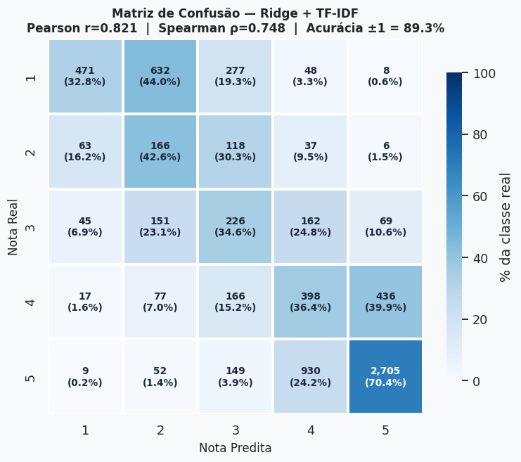

```python
from sklearn.metrics import confusion_matrix
import seaborn as sns
import matplotlib.pyplot as plt

cm     = confusion_matrix(y_test, preds_rounded, labels=[1,2,3,4,5])
cm_pct = cm / cm.sum(axis=1, keepdims=True) * 100

fig, ax = plt.subplots(figsize=(7, 6))
sns.heatmap(cm_pct, ax=ax, cmap="Blues", vmin=0, vmax=100,
            xticklabels=[1,2,3,4,5], yticklabels=[1,2,3,4,5],
            linewidths=1.5, linecolor="white", square=True,
            cbar_kws={"label": "% da classe real", "shrink": 0.8})

for i in range(5):
    for j in range(5):
        cor = "white" if cm_pct[i,j] > 50 else "#1E293B"
        ax.text(j+0.5, i+0.5,
                f"{cm[i,j]:,}\n({cm_pct[i,j]:.1f}%)",
                ha="center", va="center", fontsize=9,
                fontweight="bold", color=cor)

ax.set_title("Matriz de Confusão — Ridge + TF-IDF\n"
             f"Pearson r={pearson_r:.3f}  |  Spearman ρ={spearman_r:.3f}  |  Acurácia ±1 = {acc_1off:.1%}",
             fontsize=11, fontweight="bold")
ax.set_xlabel("Nota Predita", fontsize=11)
ax.set_ylabel("Nota Real", fontsize=11)
plt.tight_layout()
plt.show()
```

## 10. Interpretação — Palavras mais Influentes

Uma das maiores vantagens da regressão linear é a **interpretabilidade**.

Cada feature (palavra/bigrama) tem um **coeficiente** que representa seu impacto na nota:

- **Coeficiente positivo (+)** → palavra associada a notas altas (aumenta a nota estimada)
- **Coeficiente negativo (−)** → palavra associada a notas baixas (diminui a nota estimada)

Isso nos permite auditar o que o modelo "aprendeu" sobre o comportamento dos clientes.

```python
feature_names = pipe.named_steps["tfidf"].get_feature_names_out()
coef          = pipe.named_steps["ridge"].coef_

top_n   = 20
idx_pos = np.argsort(coef)[-top_n:][::-1]
idx_neg = np.argsort(coef)[:top_n]

words_pos = [(feature_names[i], coef[i]) for i in idx_pos]
words_neg = [(feature_names[i], coef[i]) for i in idx_neg]

print("Top 20 palavras/bigramas que AUMENTAM a nota (↑):")
for w, c in words_pos:
    print(f"  {w:<30} {c:+.3f}")

print()
print("Top 20 palavras/bigramas que DIMINUEM a nota (↓):")
for w, c in words_neg:
    print(f"  {w:<30} {c:+.3f}")
```

```
Top 20 palavras/bigramas que AUMENTAM a nota (↑):
  fretes                         +2.194
  preciso devolver               +2.163
  antes                          +1.932
  tive problemas                 +1.890
  sem problemas                  +1.820
  metade prazo                   +1.810
  não precisa                    +1.805
  nenhum defeito                 +1.719
  nao usei                       +1.710
  vez comprei                    +1.643
  sem avarias                    +1.628
  não abri                       +1.617
  sem defeito                    +1.598
  menos semana                   +1.586
  comprei antes                  +1.581
  testei                         +1.573
  única coisa                    +1.555
  senti falta                    +1.535
  nenhum problema                +1.532
  falta produto                  +1.526

Top 20 palavras/bigramas que DIMINUEM a nota (↓):
  não                            -3.401
  péssima                        -2.963
  não recomendo                  -2.791
  não cumpriu                    -2.611
  nao                            -2.517
  falsificado                    -2.504
  metade                         -2.448
  porcaria                       -2.424
  péssimo                        -2.420
  atrasada                       -2.322
  comprei                        -2.306
  dificuldade entrega            -2.304
  quebrado                       -2.266
  ruim                           -2.226
  inferior                       -2.225
  pessimo                        -2.208
  preço cobrado                  -2.204
  horrível                       -2.176
  réplica                        -2.161
  não funciona                   -2.149
```

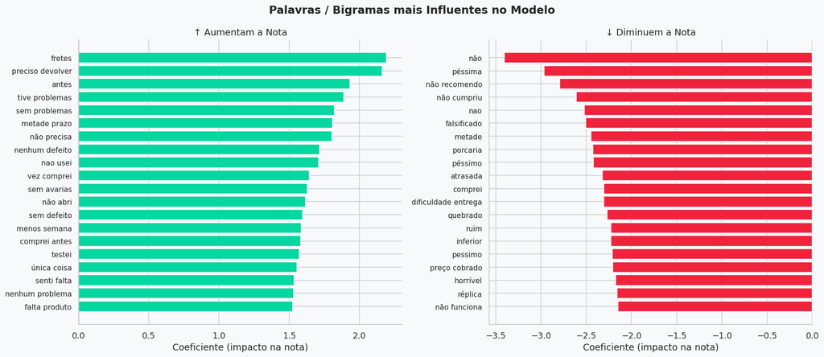

```python
fig, (ax_pos, ax_neg) = plt.subplots(1, 2, figsize=(16, 7))
fig.suptitle("Palavras / Bigramas mais Influentes no Modelo",
             fontsize=15, fontweight="bold")

# ── Positivas ────────────────────────────────────────────────────────────────
words_p = [w for w, _ in words_pos]
coefs_p = [c for _, c in words_pos]
ax_pos.barh(range(len(words_p)), coefs_p, color=PALETTE["positive"], edgecolor="white")
ax_pos.set_yticks(range(len(words_p)))
ax_pos.set_yticklabels(words_p, fontsize=10)
ax_pos.set_xlabel("Coeficiente (impacto na nota)")
ax_pos.set_title("↑ Aumentam a Nota")
ax_pos.invert_yaxis()
ax_pos.axvline(0, color="gray", linewidth=0.8)

# ── Negativas ────────────────────────────────────────────────────────────────
words_n = [w for w, _ in words_neg]
coefs_n = [c for _, c in words_neg]
ax_neg.barh(range(len(words_n)), coefs_n, color=PALETTE["negative"], edgecolor="white")
ax_neg.set_yticks(range(len(words_n)))
ax_neg.set_yticklabels(words_n, fontsize=10)
ax_neg.set_xlabel("Coeficiente (impacto na nota)")
ax_neg.set_title("↓ Diminuem a Nota")
ax_neg.invert_yaxis()
ax_neg.axvline(0, color="gray", linewidth=0.8)

plt.tight_layout()
plt.show()
```

## 11. Visualizações de Avaliação do Modelo

1. **Real vs. Predito (scatter):** pontos próximos da linha vermelha = modelo acertando. Dispersão vertical = incerteza.
2. **Distribuição do Erro:** idealmente centrada em 0. Erros maiores que ±2 pontos são casos difíceis (notas 2 e 3).
3. **Matriz de Confusão:** mostra onde o modelo acerta e onde confunde. Diagonal principal = acertos.

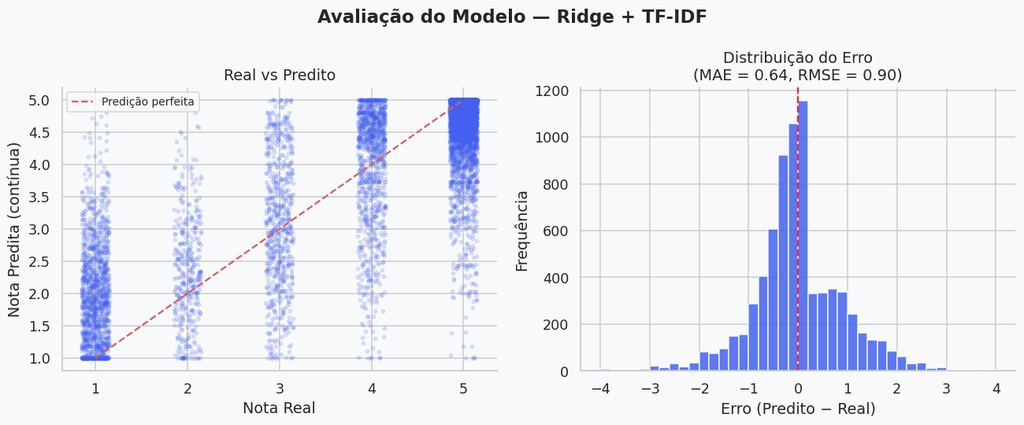

```python
fig, axes = plt.subplots(1, 2, figsize=(12, 5))
fig.suptitle("Avaliação do Modelo — Ridge + TF-IDF", fontsize=15, fontweight="bold")

# ── Real vs. Predito ─────────────────────────────────────────────────────────
ax = axes[0]
jitter = np.random.RandomState(42).uniform(-0.15, 0.15, len(y_test))
ax.scatter(y_test + jitter, preds_clipped,
           alpha=0.15, s=8, color=PALETTE["primary"])
ax.plot([1, 5], [1, 5], "r--", linewidth=1.5, label="Predição perfeita")
ax.set_xlabel("Nota Real")
ax.set_ylabel("Nota Predita (contínua)")
ax.set_title("Real vs Predito")
ax.legend(fontsize=9)

# ── Distribuição do erro ─────────────────────────────────────────────────────
ax = axes[1]
errors = preds_clipped - y_test.values
ax.hist(errors, bins=40, color=PALETTE["primary"], edgecolor="white", alpha=0.85)
ax.axvline(0, color=PALETTE["negative"], linewidth=1.5, linestyle="--")
ax.set_xlabel("Erro (Predito − Real)")
ax.set_ylabel("Frequência")
ax.set_title(f"Distribuição do Erro\n(MAE = {mae:.2f}, RMSE = {rmse:.2f})")

plt.tight_layout()
plt.show()
```

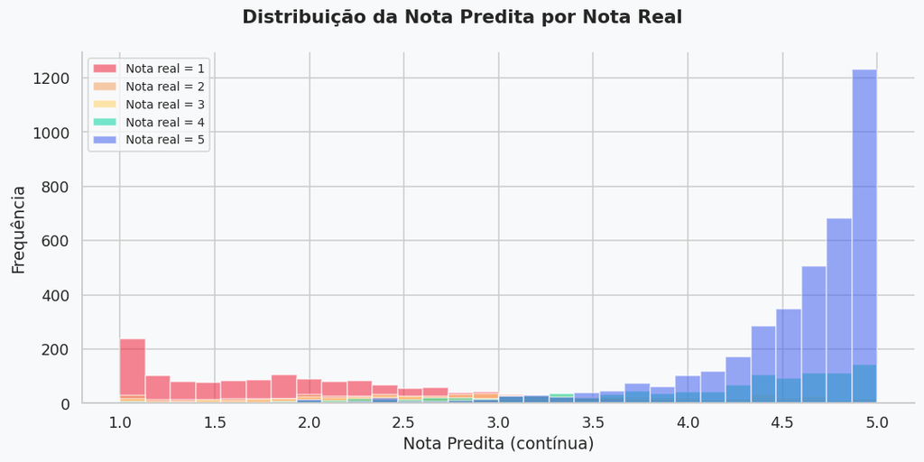

```python
# Distribuição das predições separada por nota real
# Útil para ver se o modelo diferencia bem cada classe
fig, ax = plt.subplots(figsize=(10, 5))
fig.suptitle("Distribuição da Nota Predita por Nota Real", fontsize=14, fontweight="bold")

for score in [1, 2, 3, 4, 5]:
    mask = y_test.values == score
    ax.hist(preds_clipped[mask], bins=30, alpha=0.55,
            color=SCORE_COLORS[score], label=f"Nota real = {score}", edgecolor="white")

ax.set_xlabel("Nota Predita (contínua)")
ax.set_ylabel("Frequência")
ax.legend(fontsize=9)
plt.tight_layout()
plt.show()

# Interpretação esperada:
# Notas 1 e 5 devem aparecer bem separadas nos extremos.
# Notas 2, 3 e 4 tendem a se sobrepor — são os casos mais difíceis para o modelo.
```

## 12. Predição em Novos Comentários

Aqui testamos o modelo com frases novas — que nunca foram vistas durante o treinamento.

Além da nota estimada, retornamos as **palavras que mais influenciaram** a predição naquele comentário específico, calculando o produto `coeficiente × peso_tfidf` para cada token presente.

```python
novos_comentarios = [
    "Produto chegou antes do prazo, excelente qualidade e embalagem perfeita!",
    "Péssimo! O produto veio quebrado e o atendimento foi horrível.",
    "Chegou no prazo combinado, produto razoável, nada de especial.",
    "Não recebi o produto ainda, já passou 20 dias do prazo.",
    "Super recomendo! Entrega rápida e produto idêntico à foto.",
]

print("=" * 65)
for comentario in novos_comentarios:
    res = predict_comment(comentario, pipe)
    estrelas = "⭐" * res["score_rounded"]
    print(f"\nComentário : \"{comentario[:65]}\"")
    print(f"Nota bruta : {res['score_raw']}  →  Estimada: {res['score_rounded']}/5  {estrelas}")
    if res["palavras_pos"]:
        print(f"Palavras ↑ : {res['palavras_pos']}")
    if res["palavras_neg"]:
        print(f"Palavras ↓ : {res['palavras_neg']}")
    print("-" * 65)
```

```
=================================================================

Comentário : "Produto chegou antes do prazo, excelente qualidade e embalagem pe"
Nota bruta : 4.9  →  Estimada: 5/5  ⭐⭐⭐⭐⭐
Palavras ↑ : [('perfeita', 0.354), ('antes', 0.3), ('excelente', 0.267), ('qualidade', 0.149), ('prazo', 0.095)]
Palavras ↓ : [('embalagem', -0.022), ('antes prazo', -0.034), ('produto', -0.044), ('embalagem perfeita', -0.051)]
-----------------------------------------------------------------

Comentário : "Péssimo! O produto veio quebrado e o atendimento foi horrível."
Nota bruta : 1.0  →  Estimada: 1/5  ⭐
Palavras ↑ : [('atendimento', 0.195)]
Palavras ↓ : [('produto quebrado', -0.037), ('produto', -0.054), ('quebrado', -0.963), ('péssimo', -1.055), ('horrível', -1.065)]
-----------------------------------------------------------------

Comentário : "Chegou no prazo combinado, produto razoável, nada de especial."
Nota bruta : 3.72  →  Estimada: 4/5  ⭐⭐⭐⭐
Palavras ↑ : [('combinado produto', 0.225), ('combinado', 0.217), ('chegou prazo', 0.186), ('prazo', 0.082), ('chegou', 0.018)]
Palavras ↓ : [('produto razoável', -0.018), ('produto', -0.038), ('prazo combinado', -0.042), ('especial', -0.087), ('razoável', -0.216)]
-----------------------------------------------------------------

Comentário : "Não recebi o produto ainda, já passou 20 dias do prazo."
Nota bruta : 1.51  →  Estimada: 2/5  ⭐⭐
Palavras ↑ : [('prazo', 0.092), ('dias', 0.011)]
Palavras ↓ : [('recebi', -0.03), ('produto', -0.043), ('recebi produto', -0.106), ('dias prazo', -0.14), ('produto passou', -0.242)]
-----------------------------------------------------------------

Comentário : "Super recomendo! Entrega rápida e produto idêntico à foto."
Nota bruta : 4.98  →  Estimada: 5/5  ⭐⭐⭐⭐⭐
Palavras ↑ : [('idêntico', 0.363), ('produto idêntico', 0.31), ('rápida', 0.214), ('super', 0.193), ('recomendo', 0.158)]
Palavras ↓ : [('recomendo entrega', -0.003), ('idêntico foto', -0.006), ('super recomendo', -0.015), ('foto', -0.02), ('rápida produto', -0.023)]
-----------------------------------------------------------------
```

```python
# ── Teste interativo: insira seu próprio comentário ──────────────────────────
meu_comentario = "Preciso devolver"

res = predict_comment(meu_comentario, pipe)
print(f"Comentário : {meu_comentario}")
print(f"Nota estimada: {res['score_rounded']}/5  ({'⭐' * res['score_rounded']})")
print(f"Score bruto  : {res['score_raw']}")
print(f"Palavras +   : {res['palavras_pos']}")
print(f"Palavras -   : {res['palavras_neg']}")
```

```
Comentário : Preciso devolver
Nota estimada: 4/5  (⭐⭐⭐⭐)
Score bruto  : 4.22
Palavras +   : [('preciso devolver', 1.572)]
Palavras -   : [('preciso', -0.416), ('devolver', -0.659)]
```

# ETAPA 3 - BERTimbau + TF-IDF + Sentimento + Ridge

Aqui testamos se adicionar contexto semântico (BERTimbau) e scores de sentimento melhora esse resultado.

```
BERTimbau  (768 features)   → contexto, negação, semântica
TF-IDF     (~1.773 features)→ léxico específico do domínio
LeIA       (4 features)     → intensidade do sentimento em PT-BR
VADER      (4 features)     → sentimento em inglês (referência)
TextBlob   (2 features)     → polaridade + subjetividade
─────────────────────────────────────────────────────
Total      (~2.551 features)→ Ridge Regression
```

**Hipótese:** `tb_subjectivity` pode capturar algo que o BERTimbau não captura explicitamente — a diferença entre um comentário factual ("produto vermelho") e um opinativo ("produto horrível").

⚠️ **GPU necessária:** ative em: `Ambiente de execução -> Alterar tipo -> GPU T4`

O modelo combina três tipos de informação sobre cada comentário:

**BERTimbau (768 números):** lê o comentário inteiro e gera uma representação do significado contextual — "não gostei" e "gostei" geram vetores diferentes porque o modelo entende negação e contexto.

**TF-IDF (~1.773 números):** representa o peso de cada palavra/bigrama no comentário. A maioria é zero — só as palavras que aparecem no texto têm valor. Captura o léxico específico do domínio (logística, produto, entrega).

**Sentimento (10 números):** scores calculados por três bibliotecas sobre o tom do texto — LeIA (PT-BR), VADER (inglês, entra como referência) e TextBlob (polaridade + subjetividade).

A Ridge recebe esses ~2.551 números concatenados e aprende um peso para cada um, cuja combinação resulta na nota prevista.